# Simulating diffusion networks: Using the `rdiffnet` function

## Diffusion process

An easy way to compare these three networks is by checking the cumulative adoption counts, in particular, the proportion. Using the function `plot_adopters` we can achieve our goal

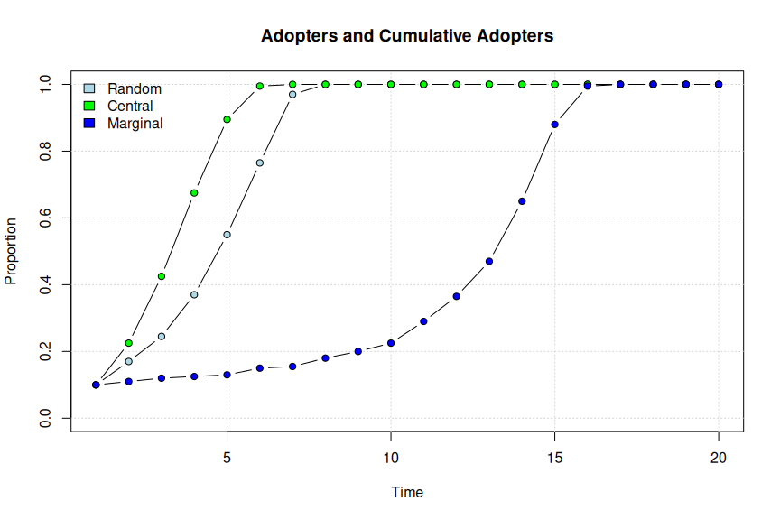

```r
plot_adopters(diffnet_ran, bg = cols[1], include.legend = FALSE, what="cumadopt")
plot_adopters(diffnet_cen, bg = cols[2], add=TRUE, what="cumadopt")
plot_adopters(diffnet_mar, bg = cols[3], add=TRUE, what="cumadopt")

legend("topleft", bty="n",
       legend = c("Random","Central", "Marginal"),
       fill=cols)
```

Comparing hazard rates we can do the following

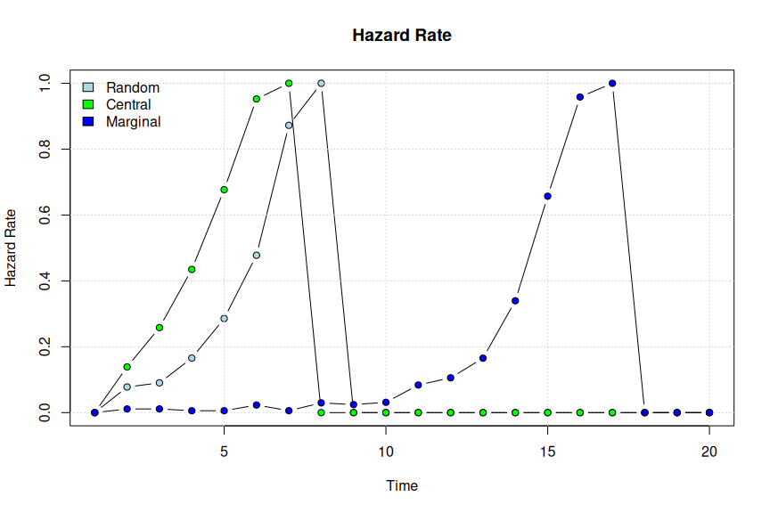

```r
plot_hazard(diffnet_ran, ylim=c(0,1), bg=cols[1])
plot_hazard(diffnet_cen, add=TRUE, bg=cols[2])
plot_hazard(diffnet_mar, add=TRUE, bg=cols[3])

legend("topleft", bty="n",
       legend = c("Random","Central", "Marginal"),
       fill=cols)
```

Furthermore, we can calculate infectiousness and susceptibility on each network and see whether both are correlated in each one of the processess.

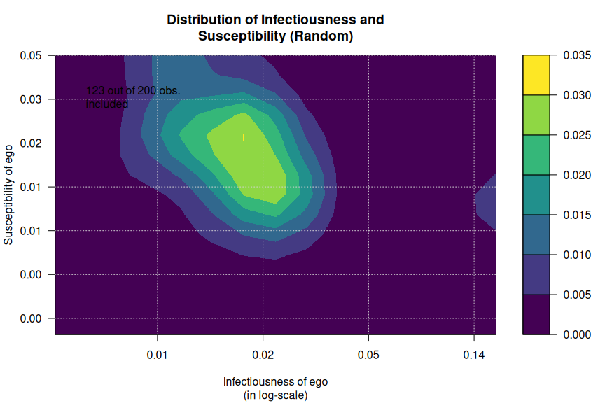

```r
plot_infectsuscep(diffnet_ran, bins=15, K=3,
                  main = "Distribution of Infectiousness and\nSusceptibility (Random)")
```

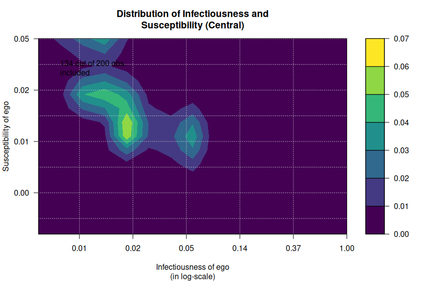

```r
plot_infectsuscep(diffnet_cen, bins=15, K=3,
                  main = "Distribution of Infectiousness and\nSusceptibility (Central)")
```

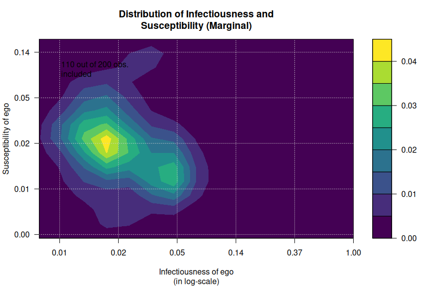

```r
plot_infectsuscep(diffnet_mar, bins=15, K=3,
                  main = "Distribution of Infectiousness and\nSusceptibility (Marginal)")
```

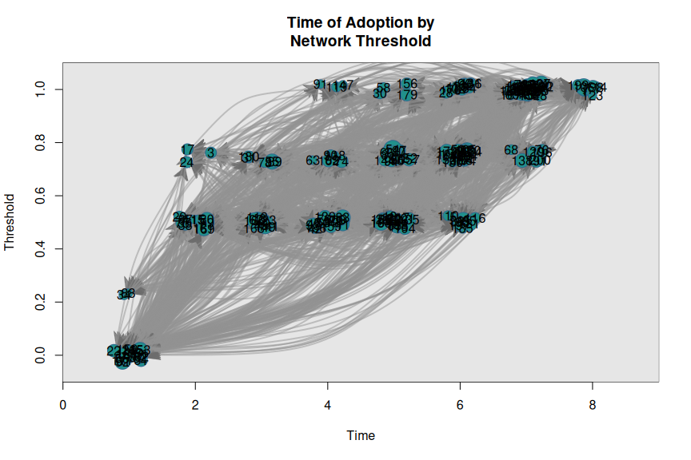

```r
plot_threshold(diffnet_ran)
```

## Multiple simulations using `rdiffnet_multiple`

The `rdiffnet_multiple` is a wrapper of `rdiffnet` that allows performing simulation studies. In particular, the user can defined a set of shared parameters across simulations and retrieve one or more statistics from each one of them. The followin example is included in the manual of the function:

```r
# Simulating a diffusion process with all the defaults but setting
# -seed.nodes- to be random
set.seed(1)
ans0 <- rdiffnet_multiple(R=50, statistic=function(x) sum(!is.na(x$toa)),
                          n = 100, t = 4, seed.nodes = "random", stop.no.diff=FALSE)
```

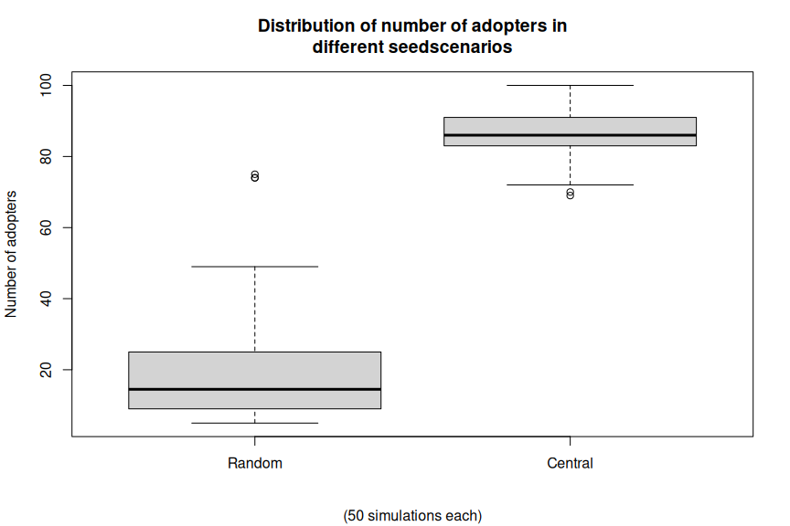

```r
# Simulating a diffusion process with all the defaults but setting
# -seed.nodes- to be central
set.seed(1)
ans1 <- rdiffnet_multiple(R=50, statistic=function(x) sum(!is.na(x$toa)),
                          n = 100, t = 4, seed.nodes = "central", stop.no.diff=FALSE)

boxplot(cbind(Random = ans0, Central = ans1),
        main="Distribution of number of adopters in\ndifferent seedscenarios",
        sub = "(50 simulations each)", ylab="Number of adopters")
```